# R Notebook

```r
library(tidyverse)
library(CodeClanData)
```

# Question 1

Take the data in the dataset qb_revenue_breakdown and make a stacked bar chart showing the sources of revenue across the two years in the dataset.

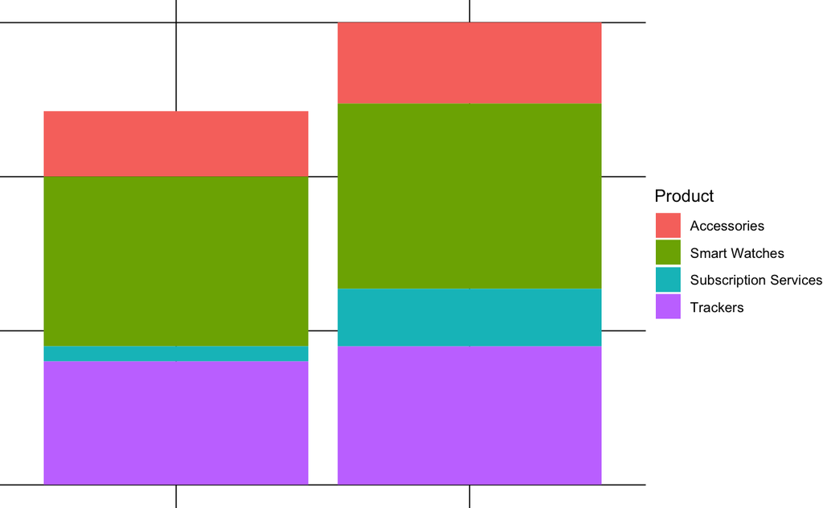

```r
qb_revenue_breakdown %>%
  ggplot() +
  aes(x = Year, y = Revenue, fill = Product) +
  geom_col() +
  theme_void() +
  theme(panel.grid.major = element_line(colour = "black"))
```

# Questino 2.

Make a line chart showing monthly sales of the “flagship product” - the ‘KwikBit Unit 1’ - over the last year. This data is inside qb_monthly_sales, but you will need to use filter() or subset() (base R).

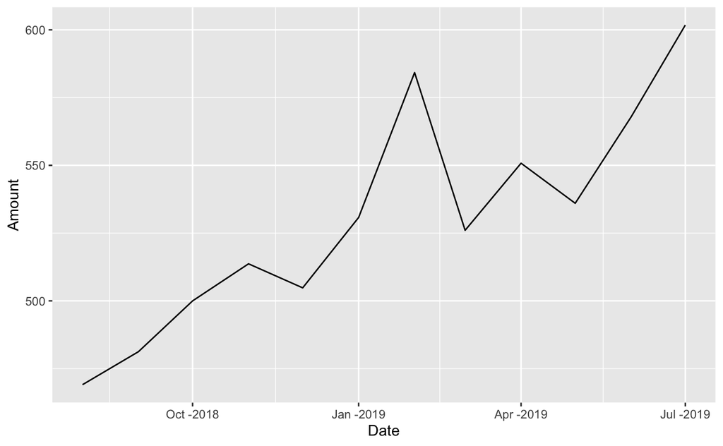

```r
library(scales)
qb_monthly_sales %>%
  filter(Cashflow == "Kwikbit Unit 1 Sales") %>%
  ggplot() +
  aes(x = Date, y = Amount) +
  geom_line() +
  scale_x_date(labels = date_format("%b -%Y"))
```

# Question 3.

Make a line chart showing monthly revenue and costs over the last year. This data is also in qb_monthly_sales.

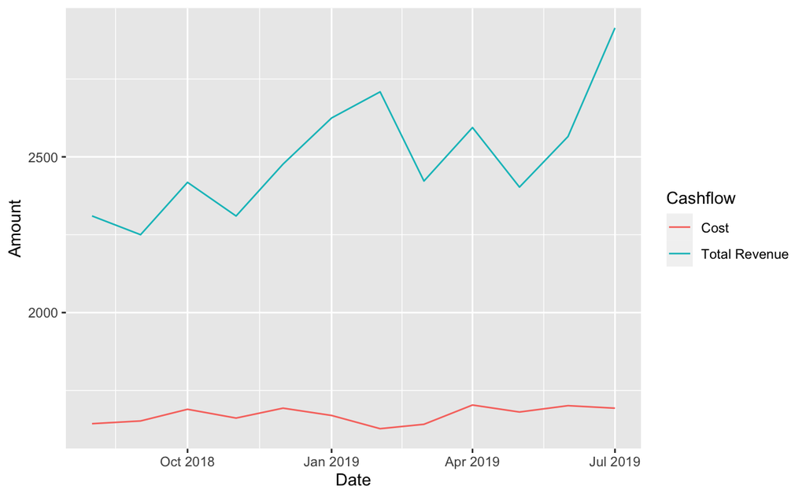

```r
qb_monthly_sales %>%
  filter(Cashflow %in% c("Total Revenue", "Cost")) %>%
  ggplot() +
  geom_line(aes(x = Date, y = Amount, colour = Cashflow ))
```

# Question 4.

Show annual sales of personal fitness trackers over the last 5 years broken down by company as a ribbon plot (use geom_area). This data is in qb_competitors.

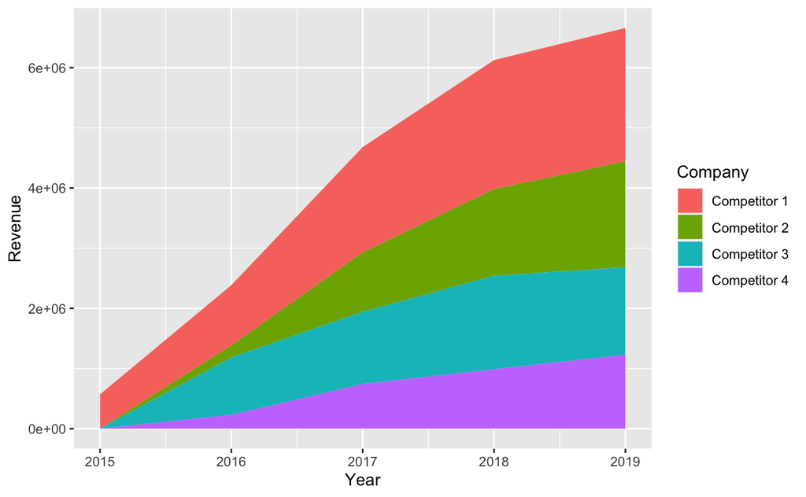

```r
qb_competitors %>%
  ggplot()+
  geom_area(aes(Year, Revenue, fill = Company))
```

# Question 5

Now show the sales from the four competitors as a line graph. Include an extra layer that shows the data points used to make the lines.

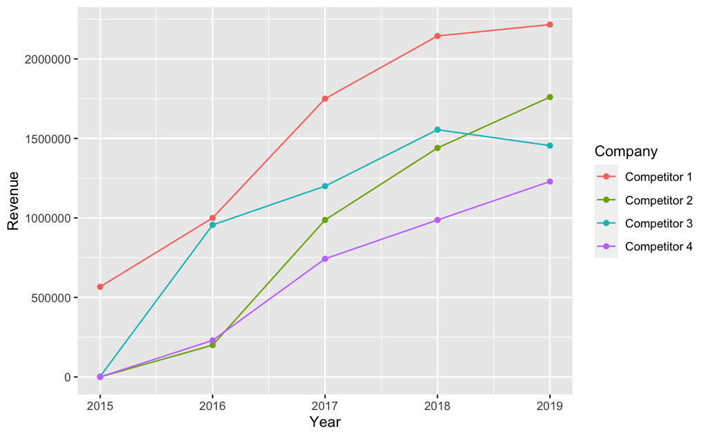

```r
qb_competitors %>%
  ggplot() +
  aes(Year, Revenue, colour = Company) +
  geom_line() +
  geom_point()
```

```r
NA
```

# Question 6

Now the company wants to compare the number of steps that their device counts vs. their competitors. Make a line graph of the number of steps throughout time, and use faceting to compare between companies and people. The data for this is in qb_device_data.

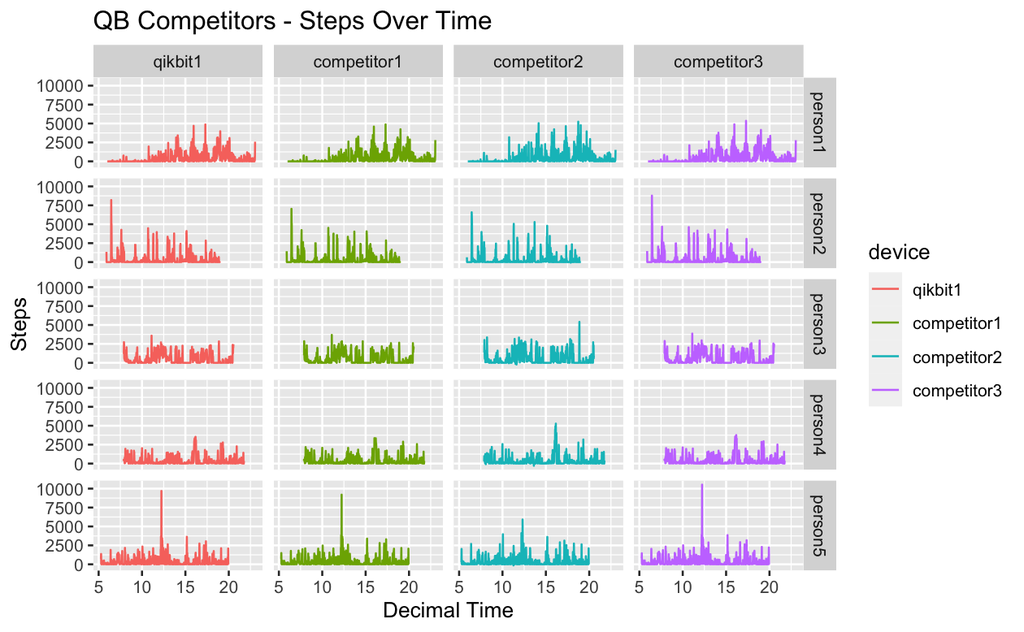

```r
qb_device_data %>%
  mutate(
    time = hours + (mins/60)
  ) %>%
  ggplot() +
  aes(time, counts, colour = device) +
  geom_line() +
  facet_grid(id~device) +
  labs(title = "QB Competitors - Steps Over Time",
       y = "Steps",
       x = "Decimal Time",
       legend.title = "A")
```

```r
monthly_sales <- read_csv("data/monthly_sales.csv")
```

[output not shown]